# Practical Machine Learning Course Project

Suleman Wadur

December 27, 2017

```r
knitr::opts_chunk$set(echo = TRUE, cache = TRUE)
```

## Summary

This documents provides a summary report of the result of my attempt to predict the class of exercise given certain data that were captured by 6 participants wearing personal activity devices such as Jawbone, Fitbit etc. The prediction is attempted using the Machine Learning approach of using training data to build a model, and finally using the model to predict the outcome of a sample test data to determine the exercise classes.

### About the data

The data is based on the information captured when 6 pearticipants performed barbell lifts in 5 different ways, refered to as a “classe”. Further information regarding the data can be found at http://groupware.les.inf.puc-rio.br/har (Section: Weight Lifting Exercise Dataset)

Training data: https://d396qusza40orc.cloudfront.net/predmachlearn/pml-training.csv  
Testing data: https://d396qusza40orc.cloudfront.net/predmachlearn/pml-testing.csv

#### Libraries

This section loads all needed libraries. Am suppressing both warnings and messages for this section to make a cleaner report.

```r
## Load Libraries

library(ggplot2)
library(caret)
library(kernlab)
library(randomForest)
```

#### Data Load and Prep

This section will get and load data. It will also perform initial data cleansing and prepping for model training.

```r
## Get data
## file check and data download
if(!file.exists("./pml-training.csv") && !file.exists("./pml-testing.csv") ) {
  fileUrl <- "https://d396qusza40orc.cloudfront.net/predmachlearn/pml-training.csv"
  download.file(fileUrl, destfile="./pml-training.csv")

  fileUrl <- "https://d396qusza40orc.cloudfront.net/predmachlearn/pml-testing.csv"
  download.file(fileUrl, destfile="./pml-testing.csv")
}


## Read data files and identifying bad values.
 trainingData <- read.csv("pml-training.csv", na.strings = c("#DIV/0!", "NA",""))
 testingData <- read.csv("pml-testing.csv", na.strings = c("#DIV/0!", "NA",""))


## Lets summarize the raw data to identity features that can be used in making the predictions.
## To predict the outcome of the class of exercise, we have to look at a measurement of the activities performed.
## Most of the features needed should be based on the information recorded by the devices. Here are the first set of variables to remove.
 #"X"
 #"user_name"
 #"raw_timestamp_part_1"
 #"raw_timestamp_part_2"
 #"cvtd_timestamp"
 #"new_window"
 #"num_window"
 #summary(trainingData)

 ## exclude the irrelevant variables
 training <- trainingData[,-c(1:7)]
 testing <- testingData[,-c(1:7)]
```

```r
 # Next is to remove variables with a high number of missing values. This is because most of these will have very little variability and not good predictors
 # I will use the nearZeroVar function to eliminate these variables right away. These are variables with nsv = TRUE.
 nsv <- nearZeroVar(training, saveMetrics = TRUE)
 head(nsv, 10)
```

```
##                      freqRatio percentUnique zeroVar   nzv
## roll_belt             1.101904     6.7781062   FALSE FALSE
## pitch_belt            1.036082     9.3772296   FALSE FALSE
## yaw_belt              1.058480     9.9734991   FALSE FALSE
## total_accel_belt      1.063160     0.1477933   FALSE FALSE
## kurtosis_roll_belt    2.000000     2.0130466   FALSE FALSE
## kurtosis_picth_belt   1.333333     1.6053409   FALSE FALSE
## kurtosis_yaw_belt     0.000000     0.0000000    TRUE  TRUE
## skewness_roll_belt    2.000000     2.0028539   FALSE FALSE
## skewness_roll_belt.1  1.333333     1.7123637   FALSE FALSE
## skewness_yaw_belt     0.000000     0.0000000    TRUE  TRUE
```

```r
 training <- training[,-(nearZeroVar(training))]
 testing <- testing[,-(nearZeroVar(testing))]
```

Next is to further remove noise from the data. Initially, an attempt to run prcomp on the training data to identify principal variables failed due to more missing data. Again, below are some of these variables

```r
 #Run prcomp to perform PCA to further reduce variables with noise
 #prcomp(training)

 # PRCOMP result in error due to variables with missing values. So I will remove these variables with any missing values
 n <- data.frame(sapply(training, function(x) sum(is.na(x))) )
 colnames(n) <- c("NA_Cnt")
 n$var <- rownames(n)
 n <- n[order(n$NA_Cnt, decreasing = TRUE), c(2,1)]

  # Display some of the variables with any missing values. These will also be removed in the next steps
 message ("Output of variables along with the total number of missing values")
```

```
## Output of variables along with the total number of missing values
```

```r
 print(head(n[n$NA_Cnt > 0, ], 10), row.names = FALSE)
```

```
##                     var NA_Cnt
##  kurtosis_picth_forearm  19301
##  skewness_pitch_forearm  19301
##   kurtosis_roll_forearm  19300
##         max_yaw_forearm  19300
##         min_yaw_forearm  19300
##   skewness_roll_forearm  19299
##      kurtosis_picth_arm  19296
##      skewness_pitch_arm  19296
##       kurtosis_roll_arm  19294
##       skewness_roll_arm  19293
```

```r
  # Remove variables with missing values and store in new dataset
 newTraining <- training[, colSums(is.na(training)) == 0 ]
 newTesting <- testing[, colSums(is.na(testing)) == 0 ]
```

### Cross Validation and PCA

Cross Validation: The training data is split into sub-training/test sets into ito to build a model on the sub-training. The model is then evaluated on the test set and estimated errors are reviewed. The sub-training data will represent 75% of the training data while the remaining will be used as sub-test data.

PCA: As part of the cross-validation, I will perform a Principal Component Analysis (PCA) on the training data in order to identify variables that are essential in the model prediction. This will be done using preProcess function.

```r
# create train and test sets for cross validation
 set.seed(33833)
 inTrain <- createDataPartition(y=newTraining$classe,p=0.75, list=FALSE)
 train <- newTraining[inTrain,]
 test <- newTraining[-inTrain,]

  # run PCA on all the variables except the outcome. This will determine the number of components in order
 # to capture 95 percent variance.
 preProc <- preProcess(train[,-53],method="pca", thresh = .95)
 numComp <- preProc$numComp
```

There will be 25 variables that are regarded as principal components in determing the “classe” of exercise per a 95% treshold analysis. Below is a plot

The next step is to compute the new dataset for the Principal Components. This will be used to run the model between the outcome and the principal components.

Principal Components of the sub-test data from the training dataset is computed and a confusion matrix is used to compare the results

```r
#featurePlot(x=train[,-53], y=train$classe, plot ="pairs")

#create PCA dataset to run against training data
trainingPC <- predict(preProc,train[,1:52])

#use randomForest to fit the model between the outcome from training data and the principal components
modelFit <- randomForest(train$classe ~ .,   data=trainingPC)
print(modelFit)
```

```
##
## Call:
##  randomForest(formula = train$classe ~ ., data = trainingPC)
##                Type of random forest: classification
##                      Number of trees: 500
## No. of variables tried at each split: 5
##
##         OOB estimate of  error rate: 2.24%
## Confusion matrix:
##      A    B    C    D    E class.error
## A 4152   12   14    5    2 0.007885305
## B   47 2761   33    3    4 0.030547753
## C    3   31 2504   24    5 0.024542267
## D    3    6   90 2309    4 0.042703151
## E    2   10   17   15 2662 0.016260163
```

```r
modelFit$importance
```

```
##      MeanDecreaseGini
## PC1          647.6662
## PC2          503.6712
## PC3          548.9374
## PC4          384.7969
## PC5          600.9027
## PC6          475.5331
## PC7          436.9940
## PC8          763.8941
## PC9          570.3155
## PC10         416.5990
## PC11         366.9667
## PC12         634.3319
## PC13         380.6882
## PC14         720.2439
## PC15         502.1455
## PC16         453.6064
## PC17         470.9496
## PC18         302.2442
## PC19         353.9137
## PC20         385.9740
## PC21         428.7309
## PC22         440.5917
## PC23         252.4681
## PC24         260.5816
## PC25         331.9234
```

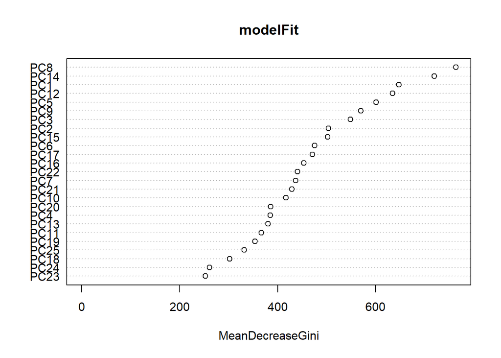

```r
#plot the very important Principal components that's used in the model.
 varImpPlot(modelFit)
```

```r
testingPC <- predict(preProc, test[,1:52])
predTest <- predict(modelFit,testingPC)
confusionMatrix(test$classe, predTest)
```

```
## Confusion Matrix and Statistics
##
##           Reference
## Prediction    A    B    C    D    E
##          A 1384    5    3    3    0
##          B   12  923   13    0    1
##          C    2   14  830    9    0
##          D    1    0   26  777    0
##          E    0    3   13    4  881
##
## Overall Statistics
##
##                Accuracy : 0.9778
##                  95% CI : (0.9732, 0.9817)
##     No Information Rate : 0.2853
##     P-Value [Acc > NIR] : < 2.2e-16
##
##                   Kappa : 0.9719
##  Mcnemar's Test P-Value : NA
##
## Statistics by Class:
##
##                      Class: A Class: B Class: C Class: D Class: E
## Sensitivity            0.9893   0.9767   0.9379   0.9798   0.9989
## Specificity            0.9969   0.9934   0.9938   0.9934   0.9950
## Pos Pred Value         0.9921   0.9726   0.9708   0.9664   0.9778
## Neg Pred Value         0.9957   0.9944   0.9864   0.9961   0.9998
## Prevalence             0.2853   0.1927   0.1805   0.1617   0.1799
## Detection Rate         0.2822   0.1882   0.1692   0.1584   0.1796
## Detection Prevalence   0.2845   0.1935   0.1743   0.1639   0.1837
## Balanced Accuracy      0.9931   0.9851   0.9658   0.9866   0.9969
```

```r
#qplot(classe, predTest, colour=classe, data = test)
```

The model build seems to predict the “classe” of the sub train/test data with a 97% accuracy. With this I will run the model against the set of 20 test cases to predict their outcomes.

```r
#applying model on 20 test cases
newTestingPC <- predict(preProc, newTesting[1:52])
#pred2 <- predict(modelFit,newTesting)
pred2 <- predict(modelFit, newTestingPC)
pred2
```

```
##  1  2  3  4  5  6  7  8  9 10 11 12 13 14 15 16 17 18 19 20
##  B  A  C  A  A  E  D  B  A  A  A  C  B  A  E  E  A  B  B  B
## Levels: A B C D E
```

#### Conclusion

The result of the specificity and sensitivity also shows that each class of exercise were highly identifiable using the model.